# Logistic regression interactions

Clay Ford

2022-09-19

Let’s fit a binary logistic regression model with an interaction. The predictors, `x1` and `x2` are both 2-level categorical variables. Notice the interaction, `x1:x2`, is highly significant.

```r
m <- glm(y ~ x1 + x2 + x1:x2, data = d, family = binomial)
summary(m)
```

```
##
## Call:
## glm(formula = y ~ x1 + x2 + x1:x2, family = binomial, data = d)
##
## Deviance Residuals:
##     Min       1Q   Median       3Q      Max
## -2.0041  -1.0268   0.5369   1.0778   1.5284
##
## Coefficients:
##             Estimate Std. Error z value Pr(>|z|)
## (Intercept)  -0.3651     0.1695  -2.155   0.0312 *
## x11           0.6040     0.2389   2.528   0.0115 *
## x21          -0.4304     0.2391  -1.800   0.0718 .
## x11:x21       2.0556     0.3785   5.430 5.62e-08 ***
## ---
## Signif. codes:  0 '***' 0.001 '**' 0.01 '*' 0.05 '.' 0.1 ' ' 1
##
## (Dispersion parameter for binomial family taken to be 1)
##
##     Null deviance: 829.37  on 599  degrees of freedom
## Residual deviance: 711.96  on 596  degrees of freedom
## AIC: 719.96
##
## Number of Fisher Scoring iterations: 4
```

How can we better understand this interaction?

One way is **effect displays**. This is basically predicted probabilities at specific levels. Notice in the effect display below that the effect of `x1` changes depending on the level of `x2`. The effect of `x1` is much greater when `x2 = 1` (the blue line). The effect of `x1` is not as pronounced when `x2 = 0`. This is a textbook example of an interaction. What’s the effect of `x1`? It depends on `x2`.

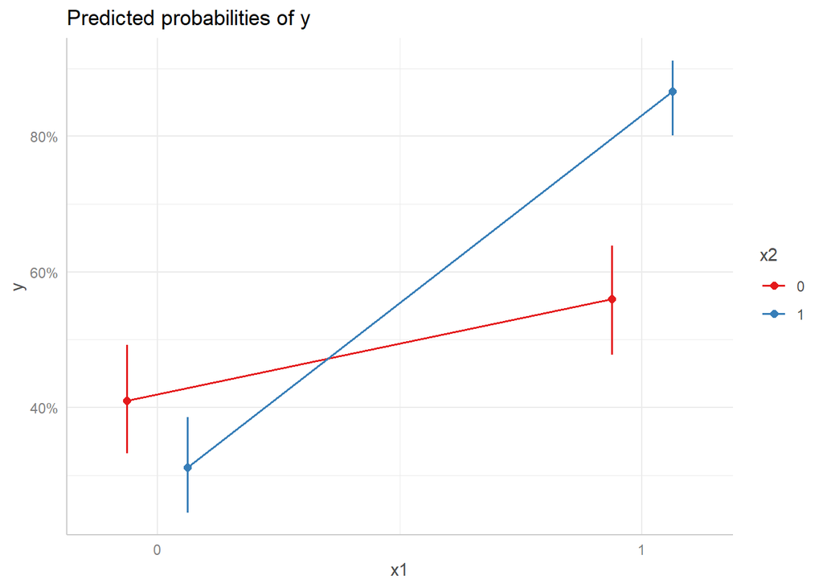

Another way to understand interactions is to compute **differences in estimated probabilities** using the model. Below we estimate probabilities for `y` at the two levels of `x2`, conditional on `x1`. You’ll notice these are the probabilities that are plotted above. The `contrasts` section shows the difference in estimated probabilities for `x2` at each level of `x1`. When `x1 = 0`, the estimated difference in probabilities between each level of `x2` is not significant at the 0.05 level. However when `x1 = 1`, the estimated difference of 0.3063 between the two levels of `x2` is significant.

```
## $emmeans
## x1 = 0:
##  x2  prob     SE  df asymp.LCL asymp.UCL
##  0  0.410 0.0410 Inf     0.329     0.490
##  1  0.311 0.0361 Inf     0.240     0.382
##
## x1 = 1:
##  x2  prob     SE  df asymp.LCL asymp.UCL
##  0  0.559 0.0415 Inf     0.478     0.641
##  1  0.866 0.0279 Inf     0.811     0.921
##
## Confidence level used: 0.95
##
## $contrasts
## x1 = 0:
##  contrast  estimate     SE  df z.ratio p.value
##  x21 - x20  -0.0987 0.0546 Inf  -1.807  0.0708
##
## x1 = 1:
##  contrast  estimate     SE  df z.ratio p.value
##  x21 - x20   0.3063 0.0500 Inf   6.122  <.0001
```

Confidence intervals give a more complete picture. When `x1 = 1`, the estimated difference in probabilities between the levels of `x2` is about (0.2, 0.4).

```
## $emmeans
## x1 = 0:
##  x2  prob     SE  df asymp.LCL asymp.UCL
##  0  0.410 0.0410 Inf     0.329     0.490
##  1  0.311 0.0361 Inf     0.240     0.382
##
## x1 = 1:
##  x2  prob     SE  df asymp.LCL asymp.UCL
##  0  0.559 0.0415 Inf     0.478     0.641
##  1  0.866 0.0279 Inf     0.811     0.921
##
## Confidence level used: 0.95
##
## $contrasts
## x1 = 0:
##  contrast  estimate     SE  df asymp.LCL asymp.UCL
##  x21 - x20  -0.0987 0.0546 Inf    -0.206   0.00835
##
## x1 = 1:
##  contrast  estimate     SE  df asymp.LCL asymp.UCL
##  x21 - x20   0.3063 0.0500 Inf     0.208   0.40440
##
## Confidence level used: 0.95
```

Finally a more traditional way to understand interactions is to use odds ratios. I find these more difficult to explain and understand.

When `x1 = 0` the model coefficients simplify as follows:

$$y = -0.365 + 0.604(0) + -0.430\text{x2}
+ 2.055(0)x2$$

$$y = -0.365 +
-0.430\text{x2}$$

Exponentiating the coefficient for `x2` gives an odds ratio.

```r
exp(-0.4304)
```

```
## [1] 0.6502489
```

When `x1 = 1` the model coefficients simplify as follows:

$$y = -0.365 + 0.604(1) + -0.430\text{x2}
+ 2.055(1)x2$$

$$y = 0.238 + 1.625\text{x2}$$

Exponentiating the coefficient for `x2` gives an odds ratio.

```r
exp(1.625)
```

```
## [1] 5.078419
```

When `x2 = 1` and `x1 = 1`, the odds that `y = 1` is about 5 times higher than the odds that `y = 1` when `x2 = 0` and `x1 = 1`.